# CSE445

```python
!pip3 install -U ucimlrepo
```

## DATASET

Bike sharing systems represent a new wave of bicycle rentals where membership, rental, and return are all handled automatically. These systems make it simple for users to borrow a bike from one location and drop it off at another. There are currently more than 500 bike-sharing programmes operating worldwide, with over 500 thousand bicycles. These systems are of tremendous interest now because of their significance in relation to transportation, environmental, and health issues.

Date/Time: Information about when the bike rides occurred. Weather Conditions: Parameters like temperature, humidity, wind speed, and weather type (e.g., sunny, rainy). Holiday Information: Indicating whether a particular day is a holiday or not. Rental Details: Including the number of bikes rented, both casual and registered users. Season: Categorizing the data into seasons (e.g., spring, summer, fall, winter). Working Day: Indicating whether a day is a working day or a weekend. User Type: Differentiating between casual and registered users. Rental Count: The target variable representing the number of bike rentals.

There are two dataset for day and hour with 16 and 17 entries respectively and 731 and 17379 index respectively. The datatypes are of int,object,float. There is no null count.

```python
from ucimlrepo import fetch_ucirepo

# fetch dataset
bike_sharing_dataset = fetch_ucirepo(id=275)

# data (as pandas dataframes)
X = bike_sharing_dataset.data.features
y = bike_sharing_dataset.data.targets

# metadata
print(bike_sharing_dataset.metadata)

# variable information
print(bike_sharing_dataset.variables)
```

```
{'uci_id': 275, 'name': 'Bike Sharing Dataset', 'repository_url': 'https://archive.ics.uci.edu/dataset/275/bike+sharing+dataset', 'data_url': 'https://archive.ics.uci.edu/static/public/275/data.csv', 'abstract': 'This dataset contains the hourly and daily count of rental bikes between years 2011 and…
          name     role         type demographic
0      instant       ID      Integer        None  \
1       dteday  Feature         Date        None
2       season  Feature  Categorical        None
3           yr  Feature  Categorical        None
4         mnth  Feature  Categorical        None
5           hr  Feature  Categorical        None
6      holiday  Feature       Binary        None
7      weekday  Feature  Categorical        None
8   workingday  Feature       Binary        None
9   weathersit  Feature  Categorical        None
10        temp  Feature   Continuous        None
11       atemp  Feature   Continuous        None
12         hum  Feature   Continuous        None
```

[output cut: 23 more lines]

```python
#Import necessary libraries
#for DA and array processing
import pandas as pd
import numpy as np
```

```python
#For Visualizations
import matplotlib.pyplot as plt
import seaborn as sns
from scipy.stats import norm, probplot
```

```python
#For Statistical modelling
from sklearn.model_selection import train_test_split
from sklearn.linear_model import LinearRegression
from sklearn.metrics import mean_squared_error
from sklearn.metrics import mean_absolute_error
from sklearn.model_selection import cross_val_score
from sklearn.model_selection import RandomizedSearchCV
from sklearn.linear_model import Ridge
from sklearn.model_selection import GridSearchCV
```

```python
import warnings
warnings.simplefilter(action='ignore', category=UserWarning)
warnings.simplefilter(action='ignore', category=FutureWarning)
```

```python
#Load the dataset
ddf=pd.read_csv('C:/Users/samiu/Downloads/bike+sharing+dataset/day.csv')
df=pd.read_csv('C:/Users/samiu/Downloads/bike+sharing+dataset/hour.csv')
```

```python
#Read the data
df.head()
```

|  | instant | dteday | season | yr | mnth | hr | holiday | weekday | workingday | weathersit | temp | atemp | hum | windspeed | casual | registered | cnt |
| --- | --- | --- | --- | --- | --- | --- | --- | --- | --- | --- | --- | --- | --- | --- | --- | --- | --- |
| 0 | 1 | 2011-01-01 | 1 | 0 | 1 | 0 | 0 | 6 | 0 | 1 | 0.24 | 0.2879 | 0.81 | 0.0 | 3 | 13 | 16 |
| 1 | 2 | 2011-01-01 | 1 | 0 | 1 | 1 | 0 | 6 | 0 | 1 | 0.22 | 0.2727 | 0.80 | 0.0 | 8 | 32 | 40 |
| 2 | 3 | 2011-01-01 | 1 | 0 | 1 | 2 | 0 | 6 | 0 | 1 | 0.22 | 0.2727 | 0.80 | 0.0 | 5 | 27 | 32 |
| 3 | 4 | 2011-01-01 | 1 | 0 | 1 | 3 | 0 | 6 | 0 | 1 | 0.24 | 0.2879 | 0.75 | 0.0 | 3 | 10 | 13 |
| 4 | 5 | 2011-01-01 | 1 | 0 | 1 | 4 | 0 | 6 | 0 | 1 | 0.24 | 0.2879 | 0.75 | 0.0 | 0 | 1 | 1 |

```python
#Exploring data frame,identifying Potential Errors and understanding the datatypes
pd.set_option('display.max_columns', None)
def data_overview(df, head=5):
    print(" SHAPE ".center(125,'-'))
    print('Rows:{}'.format(df.shape[0]))
    print('Columns:{}'.format(df.shape[1]))
    print(" MISSING VALUES ".center(125,'-'))
    print(df.isnull().sum())
    print(" DUPLICATED VALUES ".center(125,'-'))
    print(df.duplicated().sum())
    print(" HEAD ".center(125,'-'))
    print(df.head(3))
    print(" DATA TYPES ".center(125,'-'))
    print(df.dtypes)

data_overview(df)
```

```
----------------------------------------------------------- SHAPE -----------------------------------------------------------
Rows:17379
Columns:17
------------------------------------------------------- MISSING VALUES ------------------------------------------------------
instant       0
dteday        0
season        0
yr            0
mnth          0
hr            0
holiday       0
weekday       0
workingday    0
weathersit    0
temp          0
atemp         0
hum           0
windspeed     0
casual        0
registered    0
cnt           0
dtype: int64
----------------------------------------------------- DUPLICATED VALUES -----------------------------------------------------
0
------------------------------------------------------------ HEAD -----------------------------------------------------------
   instant      dteday  season  yr  mnth  hr  holiday  weekday  workingday
0        1  2011-01-01       1   0     1   0        0        6           0  \
1        2  2011-01-01       1   0     1   1        0        6           0
2        3  2011-01-01       1   0     1   2        0        6           0

   weathersit  temp   atemp   hum  windspeed  casual  registered  cnt
0           1  0.24  0.2879  0.81        0.0       3          13   16
1           1  0.22  0.2727  0.80        0.0       8          32   40
2           1  0.22  0.2727  0.80        0.0       5          27   32
--------------------------------------------------------- DATA TYPES --------------------------------------------------------
instant         int64
dteday         object
season          int64
yr              int64
mnth            int64
hr              int64
holiday         int64
weekday         int64
workingday      int64
weathersit      int64
temp          float64
atemp         float64
hum           float64
windspeed     float64
casual          int64
registered      int64
cnt             int64
dtype: object
```

```python
#Checking ouliers in Target varibale "cnt".

Q1 = df['cnt'].quantile(0.25)
Q3 = df['cnt'].quantile(0.75)
IQR = Q3 - Q1

# Define bounds for the outliers
lower_bound = Q1 - 1.5 * IQR
upper_bound = Q3 + 1.5 * IQR

# Identify the outliers
outliers = df[(df['cnt'] < lower_bound) | (df['cnt'] > upper_bound)]
outliers.style.background_gradient(cmap='Greys')
```

|  | instant | dteday | season | yr | mnth | hr | holiday | weekday | workingday | weathersit | temp | atemp | hum | windspeed | casual | registered | cnt |
| --- | --- | --- | --- | --- | --- | --- | --- | --- | --- | --- | --- | --- | --- | --- | --- | --- | --- |
| 5536 | 5537 | 2011-08-23 | 3 | 0 | 8 | 14 | 0 | 2 | 1 | 1 | 0.720000 | 0.651500 | 0.300000 | 0.089600 | 149 | 502 | 651 |
| 10358 | 10359 | 2012-03-12 | 1 | 1 | 3 | 17 | 0 | 1 | 1 | 2 | 0.620000 | 0.621200 | 0.380000 | 0.417900 | 87 | 557 | 644 |
| 10359 | 10360 | 2012-03-12 | 1 | 1 | 3 | 18 | 0 | 1 | 1 | 2 | 0.600000 | 0.621200 | 0.430000 | 0.194000 | 89 | 623 | 712 |
| 10382 | 10383 | 2012-03-13 | 1 | 1 | 3 | 17 | 0 | 2 | 1 | 1 | 0.700000 | 0.636400 | 0.370000 | 0.104500 | 62 | 614 | 676 |
| 10383 | 10384 | 2012-03-13 | 1 | 1 | 3 | 18 | 0 | 2 | 1 | 1 | 0.700000 | 0.636400 | 0.340000 | 0.298500 | 96 | 638 | 734 |
| 10397 | 10398 | 2012-03-14 | 1 | 1 | 3 | 8 | 0 | 3 | 1 | 1 | 0.440000 | 0.439400 | 0.820000 | 0.000000 | 34 | 628 | 662 |
| 10406 | 10407 | 2012-03-14 | 1 | 1 | 3 | 17 | 0 | 3 | 1 | 1 | 0.700000 | 0.636400 | 0.280000 | 0.089600 | 140 | 642 | 782 |
| 10407 | 10408 | 2012-03-14 | 1 | 1 | 3 | 18 | 0 | 3 | 1 | 1 | 0.700000 | 0.636400 | 0.320000 | 0.000000 | 102 | 647 | 749 |
| 10430 | 10431 | 2012-03-15 | 1 | 1 | 3 | 17 | 0 | 4 | 1 | 1 | 0.700000 | 0.636400 | 0.390000 | 0.253700 | 79 | 634 | 713 |
| 10431 | 10432 | 2012-03-15 | 1 | 1 | 3 | 18 | 0 | 4 | 1 | 1 | 0.660000 | 0.621200 | 0.440000 | 0.283600 | 98 | 648 | 746 |
| 10473 | 10474 | 2012-03-17 | 1 | 1 | 3 | 12 | 0 | 6 | 0 | 1 | 0.560000 | 0.530300 | 0.680000 | 0.164200 | 286 | 365 | 651 |
| 10474 | 10475 | 2012-03-17 | 1 | 1 | 3 | 13 | 0 | 6 | 0 | 1 | 0.600000 | 0.606100 | 0.600000 | 0.104500 | 286 | 400 | 686 |
| 10475 | 10476 | 2012-03-17 | 1 | 1 | 3 | 14 | 0 | 6 | 0 | 1 | 0.620000 | 0.621200 | 0.530000 | 0.089600 | 352 | 338 | 690 |
| 10476 | 10477 | 2012-03-17 | 1 | 1 | 3 | 15 | 0 | 6 | 0 | 1 | 0.640000 | 0.621200 | 0.530000 | 0.134300 | 357 | 322 | 679 |
| 10477 | 10478 | 2012-03-17 | 1 | 1 | 3 | 16 | 0 | 6 | 0 | 1 | 0.640000 | 0.621200 | 0.500000 | 0.000000 | 367 | 318 | 685 |
| 10478 | 10479 | 2012-03-17 | 1 | 1 | 3 | 17 | 0 | 6 | 0 | 1 | 0.640000 | 0.621200 | 0.500000 | 0.134300 | 291 | 357 | 648 |
| 10526 | 10527 | 2012-03-19 | 1 | 1 | 3 | 17 | 0 | 1 | 1 | 1 | 0.640000 | 0.621200 | 0.530000 | 0.223900 | 106 | 615 | 721 |
| 10527 | 10528 | 2012-03-19 | 1 | 1 | 3 | 18 | 0 | 1 | 1 | 1 | 0.640000 | 0.621200 | 0.570000 | 0.253700 | 120 | 681 | 801 |
| 10550 | 10551 | 2012-03-20 | 1 | 1 | 3 | 17 | 0 | 2 | 1 | 1 | 0.600000 | 0.590900 | 0.730000 | 0.194000 | 108 | 642 | 750 |
| 10551 | 10552 | 2012-03-20 | 1 | 1 | 3 | 18 | 0 | 2 | 1 | 1 | 0.600000 | 0.590900 | 0.690000 | 0.253700 | 136 | 665 | 801 |
| 10574 | 10575 | 2012-03-21 | 2 | 1 | 3 | 17 | 0 | 3 | 1 | 1 | 0.600000 | 0.590900 | 0.690000 | 0.089600 | 113 | 616 | 729 |
| 10575 | 10576 | 2012-03-21 | 2 | 1 | 3 | 18 | 0 | 3 | 1 | 1 | 0.600000 | 0.590900 | 0.690000 | 0.000000 | 152 | 627 | 779 |
| 10589 | 10590 | 2012-03-22 | 2 | 1 | 3 | 8 | 0 | 4 | 1 | 2 | 0.500000 | 0.484800 | 0.940000 | 0.089600 | 51 | 598 | 649 |
| 10598 | 10599 | 2012-03-22 | 2 | 1 | 3 | 17 | 0 | 4 | 1 | 1 | 0.660000 | 0.621200 | 0.650000 | 0.164200 | 154 | 656 | 810 |
| 10599 | 10600 | 2012-03-22 | 2 | 1 | 3 | 18 | 0 | 4 | 1 | 1 | 0.660000 | 0.621200 | 0.650000 | 0.164200 | 147 | 654 | 801 |
| 10613 | 10614 | 2012-03-23 | 2 | 1 | 3 | 8 | 0 | 5 | 1 | 2 | 0.500000 | 0.484800 | 0.940000 | 0.134300 | 47 | 615 | 662 |
| 10622 | 10623 | 2012-03-23 | 2 | 1 | 3 | 17 | 0 | 5 | 1 | 2 | 0.720000 | 0.651500 | 0.420000 | 0.164200 | 264 | 693 | 957 |
| 10623 | 10624 | 2012-03-23 | 2 | 1 | 3 | 18 | 0 | 5 | 1 | 1 | 0.700000 | 0.636400 | 0.450000 | 0.164200 | 237 | 593 | 830 |
| 10624 | 10625 | 2012-03-23 | 2 | 1 | 3 | 19 | 0 | 5 | 1 | 1 | 0.660000 | 0.621200 | 0.500000 | 0.194000 | 213 | 473 | 686 |
| 10685 | 10686 | 2012-03-26 | 2 | 1 | 3 | 8 | 0 | 1 | 1 | 1 | 0.440000 | 0.439400 | 0.620000 | 0.223900 | 32 | 625 | 657 |

[output cut: 475 more lines]

```python
#removing outliers
df = df[(df['cnt'] >= lower_bound) & (df['cnt'] <= upper_bound)]
print("shape after outliers removal :",df.shape)
```

```
shape after outliers removal : (16874, 17)
```

```python
# converting discrete variable "season" to bins
df = pd.get_dummies(df, columns=['season'], dtype=int)
df.head()
```

|  | instant | dteday | yr | mnth | hr | holiday | weekday | workingday | weathersit | temp | atemp | hum | windspeed | casual | registered | cnt | season_1 | season_2 | season_3 | season_4 |
| --- | --- | --- | --- | --- | --- | --- | --- | --- | --- | --- | --- | --- | --- | --- | --- | --- | --- | --- | --- | --- |
| 0 | 1 | 2011-01-01 | 0 | 1 | 0 | 0 | 6 | 0 | 1 | 0.24 | 0.2879 | 0.81 | 0.0 | 3 | 13 | 16 | 1 | 0 | 0 | 0 |
| 1 | 2 | 2011-01-01 | 0 | 1 | 1 | 0 | 6 | 0 | 1 | 0.22 | 0.2727 | 0.80 | 0.0 | 8 | 32 | 40 | 1 | 0 | 0 | 0 |
| 2 | 3 | 2011-01-01 | 0 | 1 | 2 | 0 | 6 | 0 | 1 | 0.22 | 0.2727 | 0.80 | 0.0 | 5 | 27 | 32 | 1 | 0 | 0 | 0 |
| 3 | 4 | 2011-01-01 | 0 | 1 | 3 | 0 | 6 | 0 | 1 | 0.24 | 0.2879 | 0.75 | 0.0 | 3 | 10 | 13 | 1 | 0 | 0 | 0 |
| 4 | 5 | 2011-01-01 | 0 | 1 | 4 | 0 | 6 | 0 | 1 | 0.24 | 0.2879 | 0.75 | 0.0 | 0 | 1 | 1 | 1 | 0 | 0 | 0 |

## Exploratory Data Analysis

[output not shown]

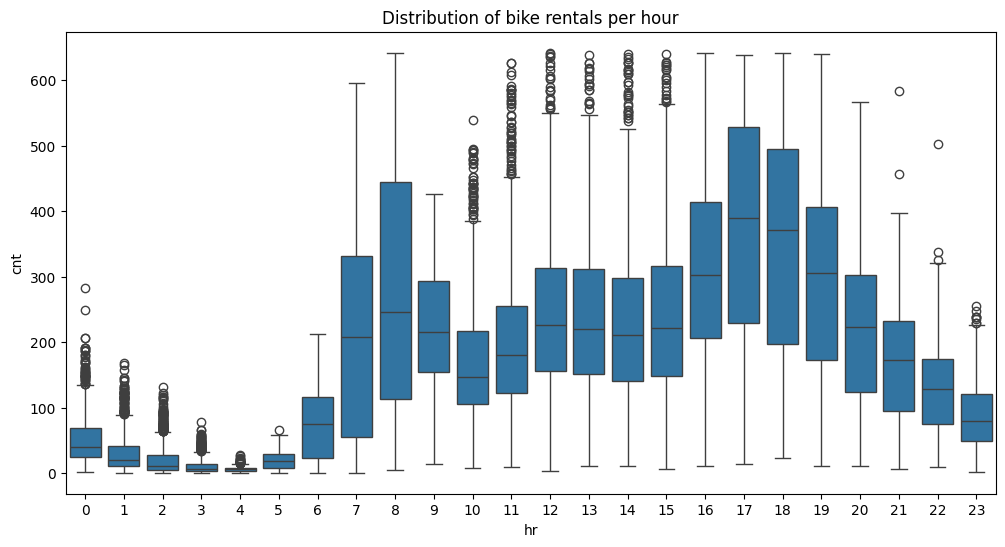

```python
#EDA
plt.figure(figsize=(12,6))
ax = sns.boxplot(x='hr', y='cnt', data=df)
plt.title('Distribution of bike rentals per hour')
for i in ax.containers:
    ax.bar_label(i,)
plt.show()
```

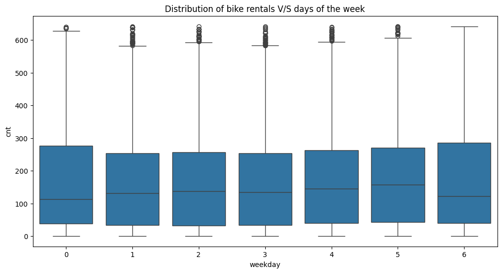

```python
plt.figure(figsize=(12,6))
sns.boxplot(x='weekday', y='cnt', data=df)
plt.title('Distribution of bike rentals V/S days of the week')
```

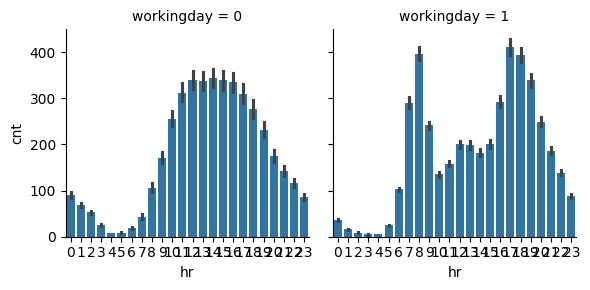

```python
plt.figure(figsize=(12,6))
d = sns.FacetGrid(df, col="workingday")
d. map(sns.barplot, "hr", "cnt")
```

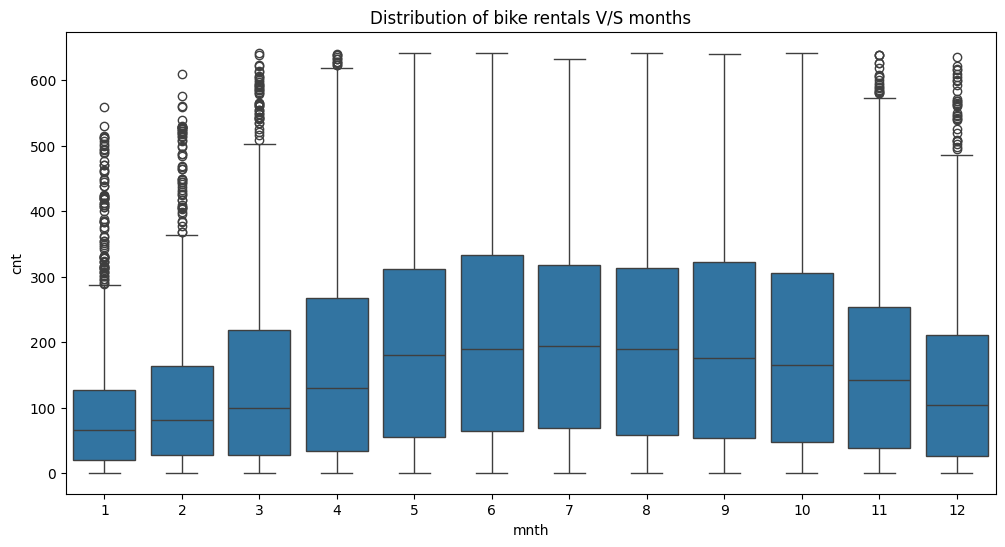

```python
plt.figure(figsize=(12,6))
sns.boxplot(x='mnth', y='cnt', data=df)
plt.title('Distribution of bike rentals V/S months')
plt.show()
```

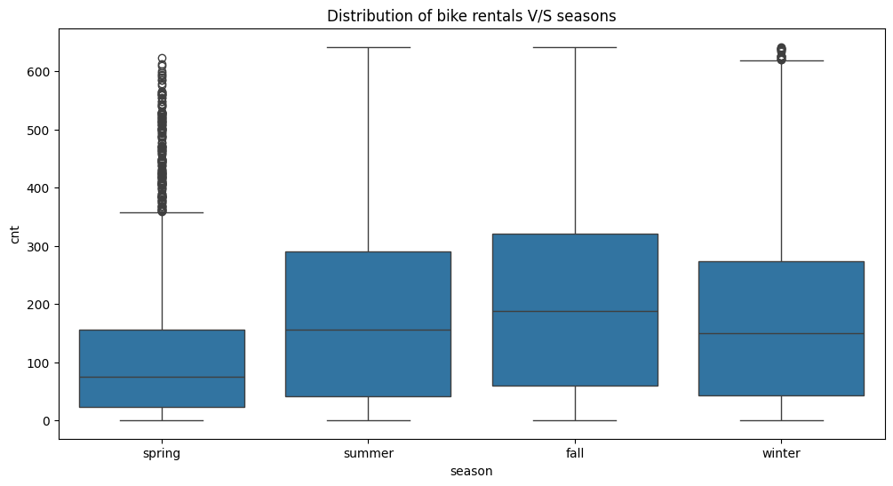

```python
df['season'] = df[['season_1', 'season_2', 'season_3', 'season_4']].idxmax(axis=1)
df['season'] = df['season'].map({'season_1': 'spring', 'season_2': 'summer', 'season_3': 'fall', 'season_4': 'winter'})
plt.figure(figsize=(12,6))
sns.boxplot(x='season', y='cnt', data=df)
plt.title('Distribution of bike rentals V/S seasons')
plt.show()
```

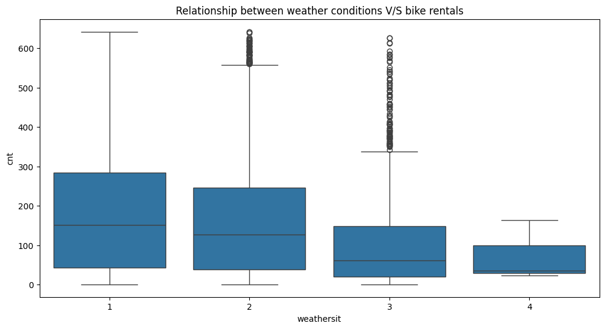

```python
plt.figure(figsize=(12,6))
sns.boxplot(x='weathersit', y='cnt', data=df)
plt.title('Relationship between weather conditions V/S bike rentals')
plt.show()
```

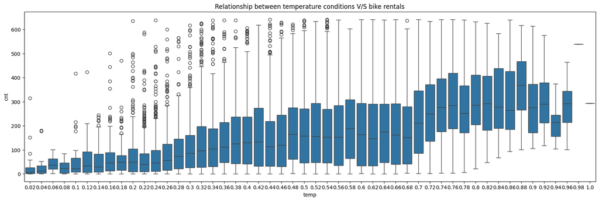

```python
plt.figure(figsize=(20,6))
sns.boxplot(x='temp', y='cnt', data=df)
plt.title('Relationship between temperature conditions V/S bike rentals')
plt.show()
```

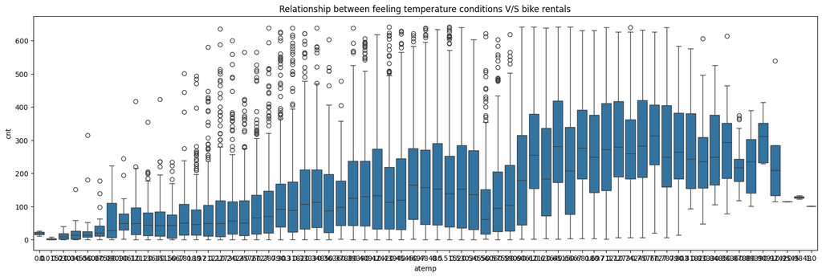

```python
plt.figure(figsize=(20,6))
sns.boxplot(x='atemp', y='cnt', data=df)
plt.title('Relationship between feeling temperature conditions V/S bike rentals')
plt.show()
```

```python
# Define a function to determine if a given hour is typically a rush hour
def is_rush_hour(hour):
    if (7 <= hour <= 9) or (17 <= hour <= 19):
        return 1
    else:
        return 0

# Apply the function to the 'hr' column to create the new 'rush_hour' feature
df['rush_hour'] = df['hr'].apply(is_rush_hour)

# Display the first few rows of the dataframe to verify the changes
df.head().style.background_gradient(cmap='Greys')
```

|  | instant | dteday | yr | mnth | hr | holiday | weekday | workingday | weathersit | temp | atemp | hum | windspeed | casual | registered | cnt | season_1 | season_2 | season_3 | season_4 | season | rush_hour |
| --- | --- | --- | --- | --- | --- | --- | --- | --- | --- | --- | --- | --- | --- | --- | --- | --- | --- | --- | --- | --- | --- | --- |
| 0 | 1 | 2011-01-01 | 0 | 1 | 0 | 0 | 6 | 0 | 1 | 0.240000 | 0.287900 | 0.810000 | 0.000000 | 3 | 13 | 16 | 1 | 0 | 0 | 0 | spring | 0 |
| 1 | 2 | 2011-01-01 | 0 | 1 | 1 | 0 | 6 | 0 | 1 | 0.220000 | 0.272700 | 0.800000 | 0.000000 | 8 | 32 | 40 | 1 | 0 | 0 | 0 | spring | 0 |
| 2 | 3 | 2011-01-01 | 0 | 1 | 2 | 0 | 6 | 0 | 1 | 0.220000 | 0.272700 | 0.800000 | 0.000000 | 5 | 27 | 32 | 1 | 0 | 0 | 0 | spring | 0 |
| 3 | 4 | 2011-01-01 | 0 | 1 | 3 | 0 | 6 | 0 | 1 | 0.240000 | 0.287900 | 0.750000 | 0.000000 | 3 | 10 | 13 | 1 | 0 | 0 | 0 | spring | 0 |
| 4 | 5 | 2011-01-01 | 0 | 1 | 4 | 0 | 6 | 0 | 1 | 0.240000 | 0.287900 | 0.750000 | 0.000000 | 0 | 1 | 1 | 1 | 0 | 0 | 0 | spring | 0 |

```python
#creating dimensions for Modelling
x_data = df.drop(['cnt', 'dteday', 'season'], axis=1)
y_data = df['cnt']
```

```python
#Spliting test and train data with standard ratio
x_train, x_test, y_train, y_test = train_test_split(x_data,y_data,test_size=0.2,random_state=1)
print("shape of x_train",x_train.shape)
print("shape of y_train",y_train.shape)
print("shape of x_test",x_test.shape)
print("shape of y_test",y_test.shape)
```

```
shape of x_train (13499, 19)
shape of y_train (13499,)
shape of x_test (3375, 19)
shape of y_test (3375,)
```

```python
#creating object, using which we could generate instances.
lm = LinearRegression()
```

```python
#Fitting model by supplying train data
lm.fit(x_train,y_train)
```

```
LinearRegression()
```

```python
yhat= lm.predict(x_test)
print("Predicted cnt for test data are:", yhat[0:5].tolist())
```

```
Predicted cnt for test data are: [307.00000000000136, 219.99999999999673, 112.99999999999389, 121.00000000000273, 5.000000000006185]
```

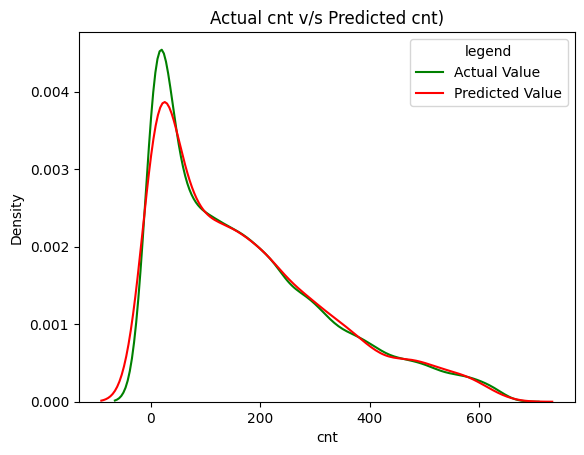

```python
plt.title("Actual cnt v/s Predicted cnt)")
ax1 = sns.distplot(y_data,hist=False,color="green",label="Actual Value")
sns.distplot(yhat,hist=False,color='red',label="Fitted Value",ax = ax1)
plt.legend(title='legend', loc='upper right', labels=['Actual Value', 'Predicted Value'])
plt.show()
```

```python
#Mean Squared Error(MSE)
mse = mean_squared_error(y_test, yhat)
print('The mean square error of cnt and predicted value is: ', mse)
```

```
The mean square error of cnt and predicted value is:  2.80687788735884e-23
```

```python
#R-Squared
print('the R-Squared value of fitted model is:',lm.score(x_train,y_train))
```

```
the R-Squared value of fitted model is: 1.0
```

## Decision

Regression is the preferred method for predictive modelling because to its interpretability, compatibility with the features of the dataset, and use of well-established performance evaluation techniques. It offers a strong basis for comprehending and forecasting bike rental numbers. Continuous goal Variable: Since "cnt" (bike rental count) is a continuous goal variable, regression is deemed appropriate for forecasting numerical results.

Relationship between Predictors: The dataset contains a number of variables that may affect the number of bike rentals, such as the season, time of day, and weather. The links between these predictors and the target variable are captured using regression. Interpretability: Regression models provide interpretability, which helps stakeholders by enabling us to comprehend how various factors influence bike rentals. Baseline Model: Prior to examining more sophisticated methods, regression functions as the fundamental baseline model for predicting tasks. Regression Performance measures: For efficient model evaluation, regression models have well-established performance measures including Mean Squared Error (MSE) and R-squared (R2).

OUTPUT: